# Draft Exploration

Chase Bookin

March 21, 2020

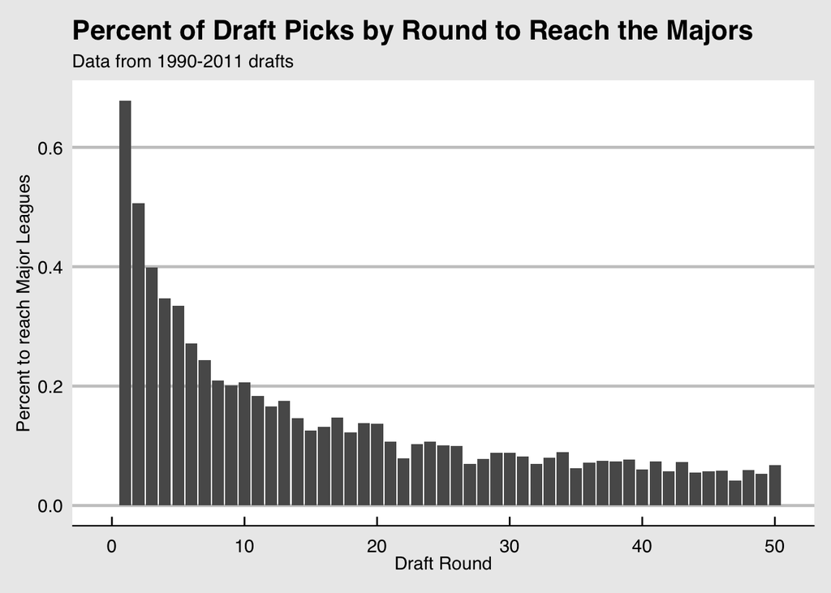

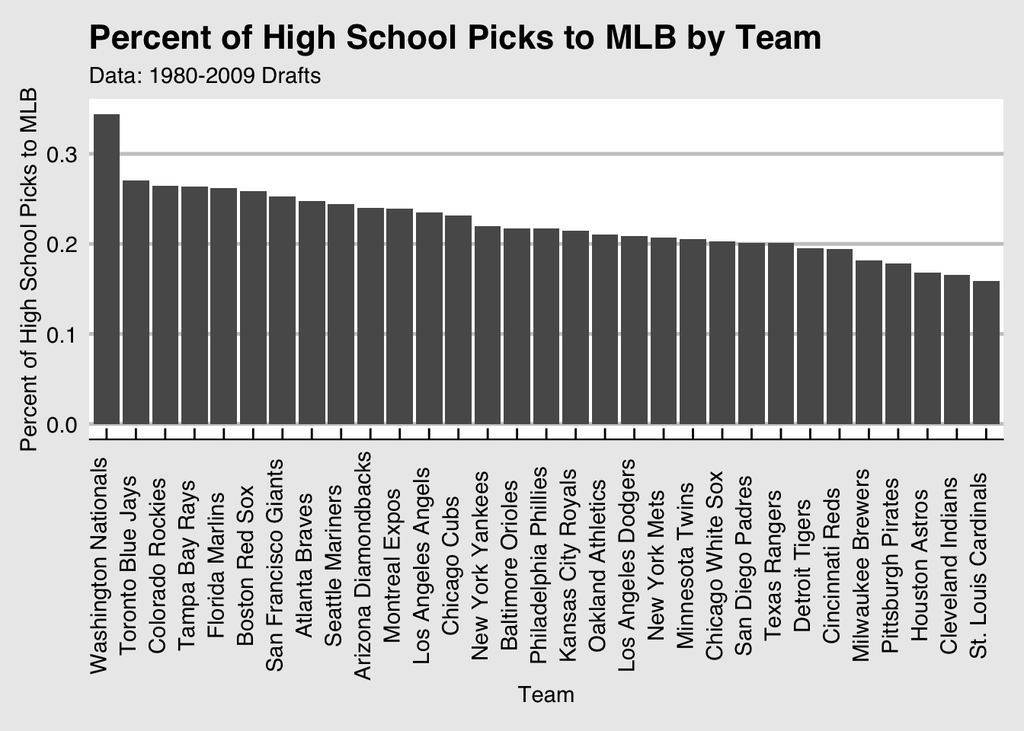

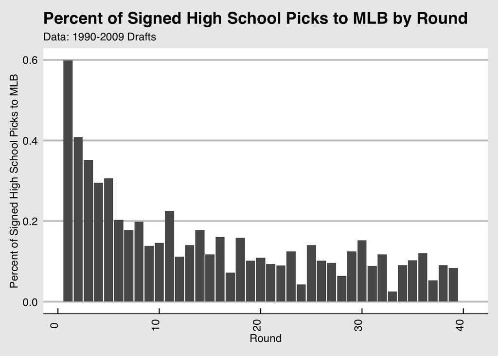

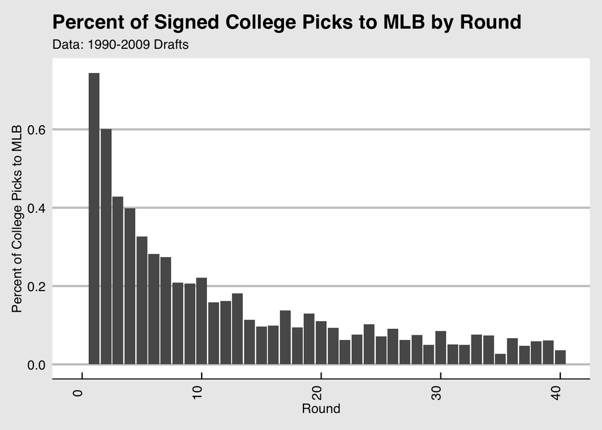

Findings from master redraft function (can be found in redraft_backup.Rmd) : 50.8 percent of players that turned down the draft out of high school from 1990-2015 were drafted again. 73.3 percent of players that turned down a top 20 round draft pick out of high school from 1990-2015 were drafted again. The average initial round of top 20 high school picks to turn down the draft was 12.99. When they are redrafted, the average pick is round 16.38, a fair drop.

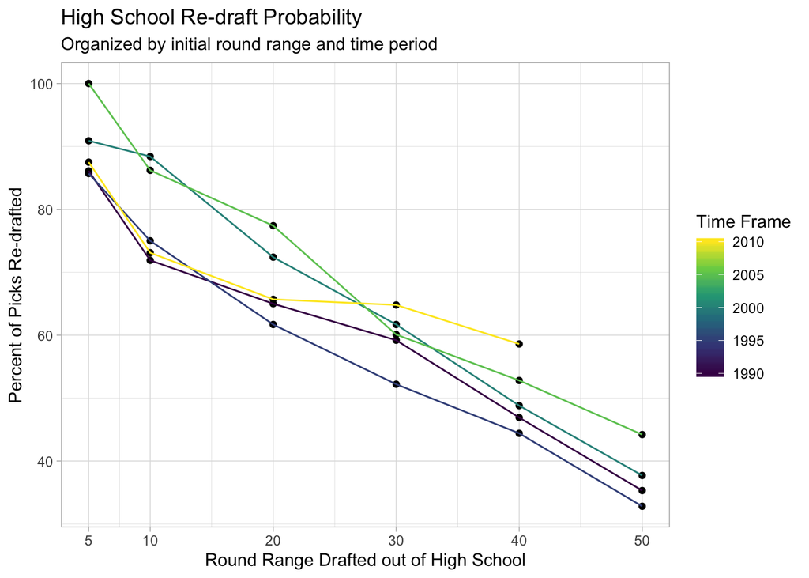

Notes on graph: most recent 5 years emulates earliest two 5 year periods but much less steep towards back end of draft. Possible explanations are teams taking late draft shots at unsignable top picks or high school picks just maintaining stock better.

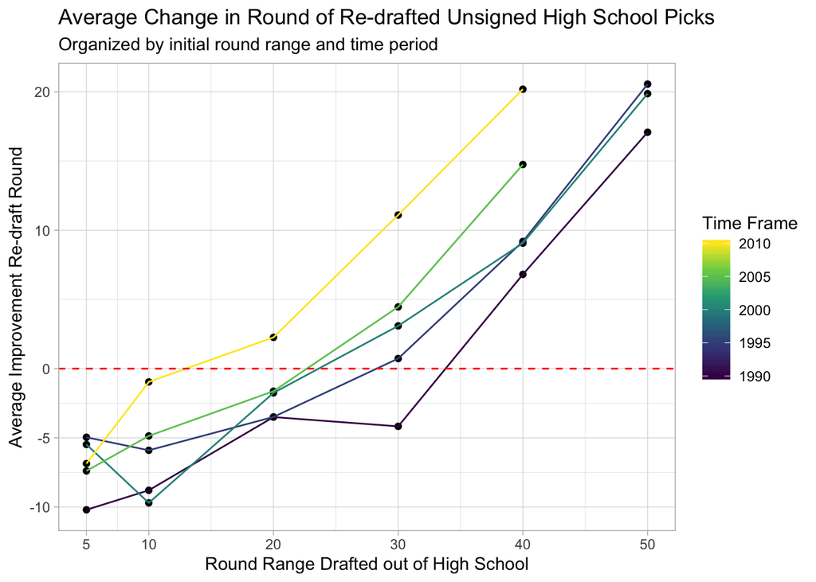

Note estimated intercept with y=0 to see when on average it becomes beneficial to a player’s redraft stock to not sign out of high school. Important to keep in mind this is for players who are redrafted, so back half of draft improvement likely partly explained by fewer, the best, initial late round high school picks being redrafted.

shiny link:

https://chase-bookin.shinyapps.io/final_project_shiny/

```
## [1] 0.2777778
```

```
## [1] 0.2283214
```

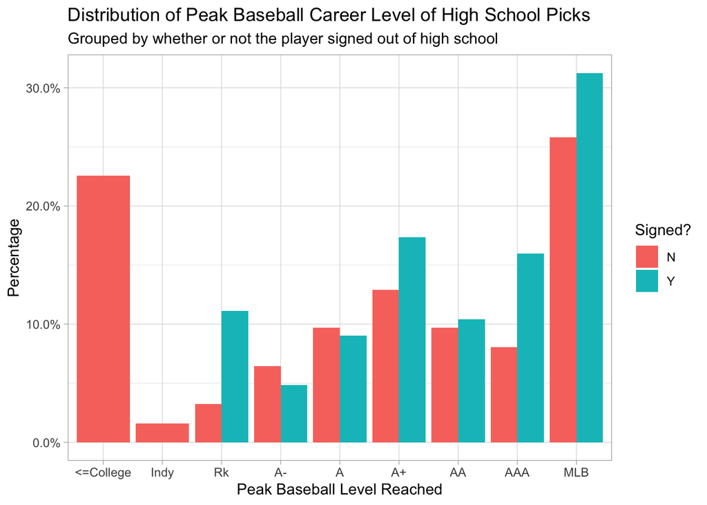

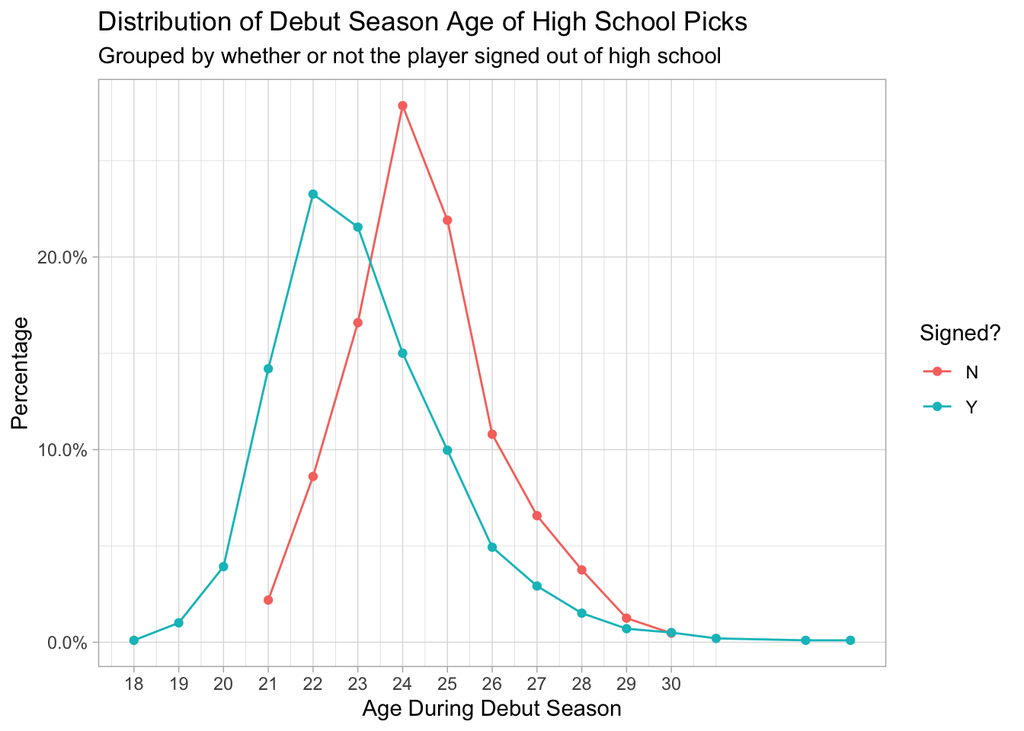

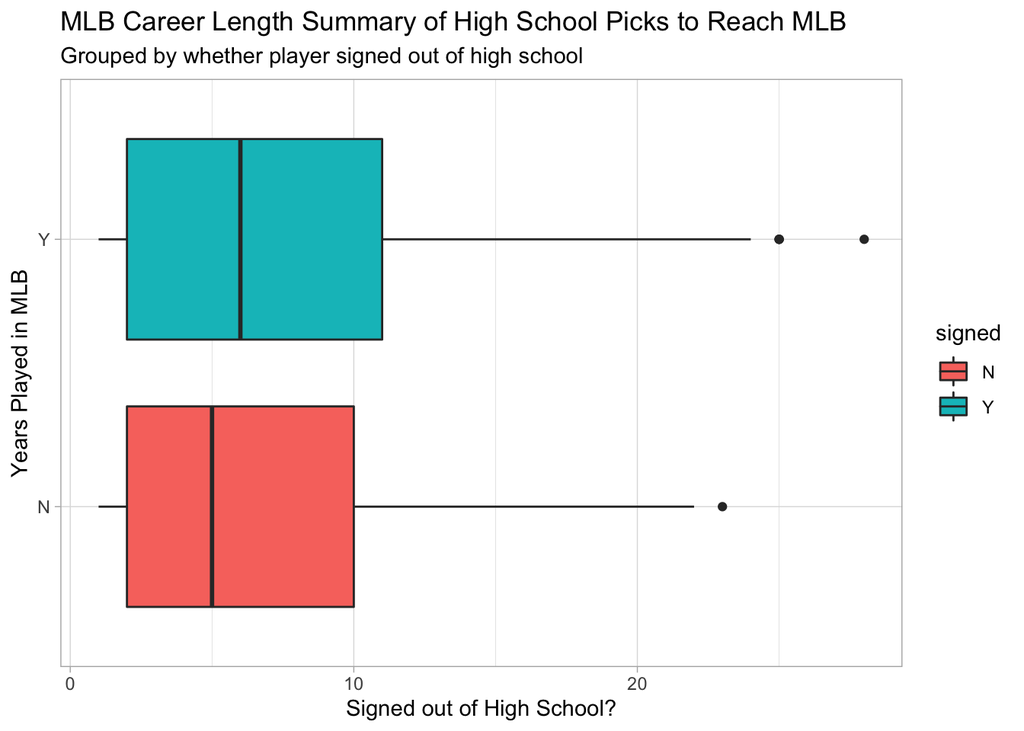

Career Wins Above Replacement of High School Picks to Reach MLB

| Grouped by whether player signed out of high school Signed? | Grouped by whether player signed out of high school 25th Percentile | Grouped by whether player signed out of high school Median | Grouped by whether player signed out of high school Mean | Grouped by whether player signed out of high school 75th Percentile |
| --- | --- | --- | --- | --- |
| N | −0.32 | 0.18 | 5.06 | 4.77 |
| Y | −0.28 | 0.53 | 7.03 | 6.92 |

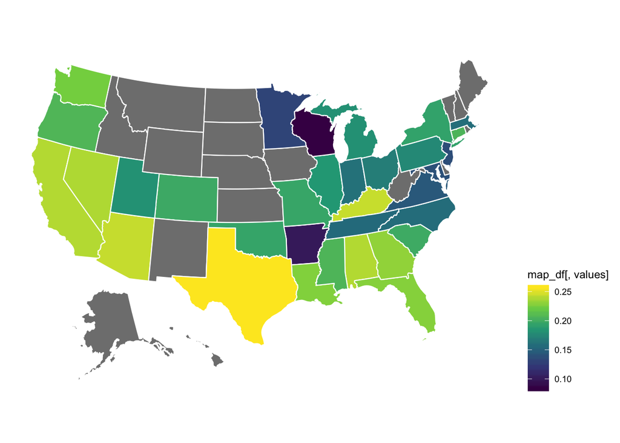

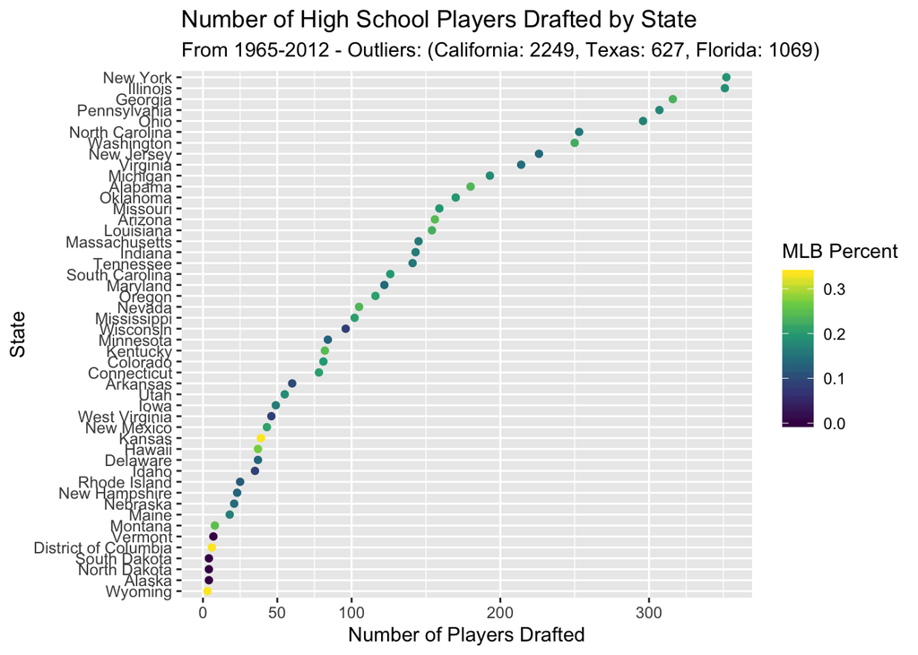